# Getting Started with OMJulia and the Dynawo Library

Simulate one of the Dynawo library examples from Julia, plot it, change a parameter and simulate again.

`Dynawo.Examples.InertialGrid.DoubleInertialGrid`: two inertial grids of 32350 MVA joined by two 120 km lines, feeding a 500 MW load. A load step at `t = 10 s` excites the inter-area oscillation between them.

## Configuration

Import the necessary packages and libraries. We must configure the `OPENMODELICALIBRARY` environment variable so the `omc` compiler knows exactly where to read the Modelica Standard Library during compilation.

```julia
using OMJulia
using Plots

# --- Configuration ---

# 1. Modelica Standard Library
OMLIB_DIR = joinpath(homedir(), ".openmodelica", "libraries")
ENV["OPENMODELICALIBRARY"] = OMLIB_DIR
MODELICA_PKG_PATH = joinpath(OMLIB_DIR, "Modelica 3.2.3+maint.om", "package.mo")

# 2. Dynawo Modelica Library
DYNAWO_PKG_PATH = abspath("dynawo_library/Dynawo/package.mo")

# 3. Model to simulate
MODEL = "Dynawo.Examples.InertialGrid.DoubleInertialGrid"
```

```
"Dynawo.Examples.InertialGrid.DoubleInertialGrid"
```

## Open an OpenModelica Session

Open a connection to OpenModelica and load the libraries the model needs. Compiling the model takes a while the first time.

```julia
# Start a background communication session with the OpenModelica compiler
omc = OMJulia.OMCSession()

# Load base Modelica libraries
sendExpression(omc, "loadModel(Complex)")
sendExpression(omc, "loadModel(ModelicaServices)")

# ModelicaSystem translates and compiles the Modelica code into C code,
# generating the simulation executable. This step may take several seconds.
ModelicaSystem(omc, DYNAWO_PKG_PATH, MODEL, [MODELICA_PKG_PATH])

getSimulationOptions(omc)
```

```
[ Info: Path to zmq file="/tmp/openmodelica.clarafercas.port.julia.lPfJeXWoQg"
```

```
Dict{Any, Any} with 5 entries:
  "startTime" => "0"
  "stopTime"  => "50"
  "solver"    => "dassl"
  "stepSize"  => "0.001"
  "tolerance" => "1e-08"
```

## Simulate and Plot

`getSolutions` reads the results from the file the simulation leaves behind, and returns the series in the same order you ask for them.

`deltaFrequency` is the difference between the two frequencies, which the example computes itself.

```julia
simulate(omc)

(t, f1, f2, deltaF) = getSolutions(omc,
    ["time",
     "inertialGrid1.reducedOrderSFR.frequency",
     "inertialGrid2.reducedOrderSFR.frequency",
     "deltaFrequency"]);
```

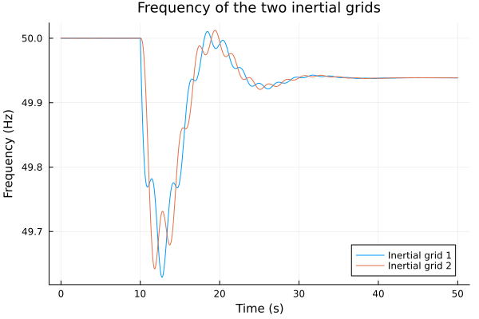

```julia
p1 = plot(t, [f1 f2], label = ["Inertial grid 1" "Inertial grid 2"])
plot!(p1, legend = :bottomright, titlefontsize = 12, labelfontsize = 10)
title!(p1, "Frequency of the two inertial grids")
xlabel!(p1, "Time (s)")
ylabel!(p1, "Frequency (Hz)")
```

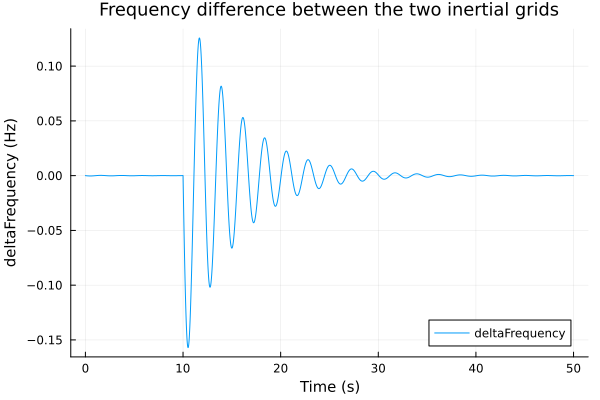

```julia
p2 = plot(t, deltaF, label = "deltaFrequency")
plot!(p2, legend = :bottomright, titlefontsize = 12, labelfontsize = 10)
title!(p2, "Frequency difference between the two inertial grids")
xlabel!(p2, "Time (s)")
ylabel!(p2, "deltaFrequency (Hz)")
```

## Change a Parameter

We change the line length from 120 to 150 km and simulate again, without initializing the model for the new length.

```julia
setParameters(omc, ["L1 = 150", "L2 = 150"])

simulate(omc)

(t_150, f1_150, f2_150, deltaF_150) = getSolutions(omc,
    ["time",
     "inertialGrid1.reducedOrderSFR.frequency",
     "inertialGrid2.reducedOrderSFR.frequency",
     "deltaFrequency"]);
```

```
L1=150

L2=150
```

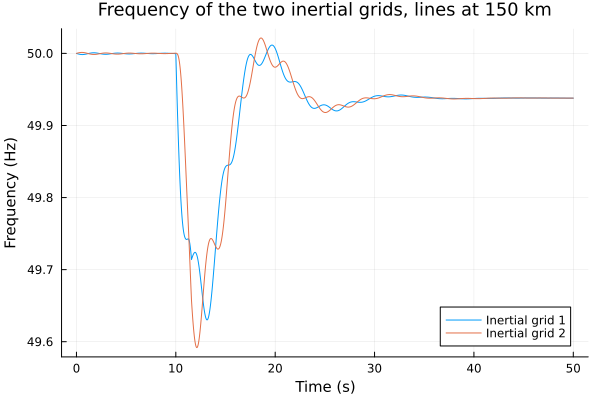

```julia
p3 = plot(t_150, [f1_150 f2_150], label = ["Inertial grid 1" "Inertial grid 2"])
plot!(p3, legend = :bottomright, titlefontsize = 12, labelfontsize = 10)
title!(p3, "Frequency of the two inertial grids, lines at 150 km")
xlabel!(p3, "Time (s)")
ylabel!(p3, "Frequency (Hz)")
```

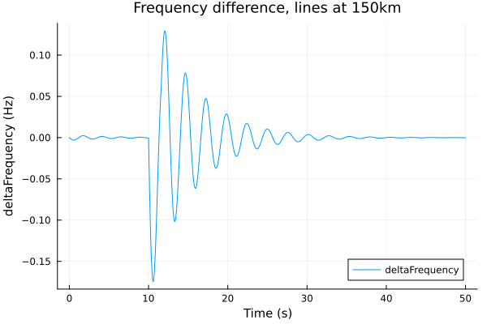

```julia
p4 = plot(t_150, deltaF_150, label = "deltaFrequency")
plot!(p4, legend = :bottomright, titlefontsize = 12, labelfontsize = 10)
title!(p4, "Frequency difference, lines at 150km")
xlabel!(p4, "Time (s)")
ylabel!(p4, "deltaFrequency (Hz)")
```

We can see oscillations before the step at `t = 10 s`. These are an effect of the model not being correctly initialized, since we maintained the operating point values of the 120 km simulation.

The other notebooks in this folder show how to initialize the model again after changing a parameter, and what can be done once it is initialized.